# WoLKE CAEO 2025 Report

- Show All Code
- Hide All Code
- View Source

Author

Heiko Holz

Published

September 25, 2025

This document contains the analysis scripts and report for the manuscript “A Course on AI for Pre-Service STEM and Language Teachers: A Quasi-Experimental Evaluation of Learning Outcomes Using Intelligent-TPACK and AI Literacy Instruments”. The R scripts, data are hosted at .

```r
library(this.path)
library(dplyr) #e.g. for select
library(tidyr) # for reshaping data
library(stringdist) #levenshtein
library(stringr) # for reshaping data
library(lme4)
library(lmerTest)
library(emmeans)
library(modelsummary)
library(kableExtra)
library(arsenal)
library(forcats)
library(ggplot2)
library(ggsci) # color palettes
library(jtools) # theme_apa etc.
library(papaja) # for apa reporting
library(sjPlot) # for tab_model
library(stargazer) # for stargazer tables
library(estimatr) # for lm_robust
source(file = "functions.r") # all outsourced funtions
```

```r
# load "env-analysis.RData" which contains all data needed for the analysis
load(file = "data/env-analysis.RData")

names(lmers_prepost_all) <- outcomes
# get the number of the terms in the model for the two treatment contrasts
tc2 <- nrow(summary(lmers_prepost_all[[1]])$coefficients)
tc1 <- tc2 - 1
```

```r
data_wtf <- data %>%
  droplevels %>%
  mutate(
    location = factor(
      location,
      levels = c("PH Schwäbisch Gmünd", "PH Ludwigsburg")
    ),
    treatment = factor(ifelse(intervention == "control", "control", "intervention"))
  )

## define contrast Control vs Exp1+Exp2 - vermutlich bessere version, da die Estimates "stimmen"
mat <- cbind(
  c(1 / 3, 1 / 3, 1 / 3), # Durchschnitt aller 3 Gruppen
  c(-1, .5, .5), # Vergleich Control vs Mittel der beiden Interventions-Gruppen
  c(0, -1, 1)) # Vergleich Sprache vs MINT
contrasts.CvsExp <- solve(t(mat))[, -1]
colnames(contrasts.CvsExp) <- c("-c+STEM_language", "-STEM+language")
contrasts(data_wtf$intervention) <- contrasts.CvsExp

# GENDER
# female: -1/2
# male : +1/2
contrasts.gender <- cbind(c(-1 / 2, 1 / 2))
colnames(contrasts.gender) <- c("-m+f")
contrasts(data_wtf$gender) <- contrasts.gender

# LOCATION
# SG UE: -1/2
# L UE: +1/2
contrasts.location <- cbind(c(-1 / 2, 1 / 2))
colnames(contrasts.location) <- c("-SGUE+LUE")
contrasts(data_wtf$location) <- contrasts.location

# TIME
# pre: -1/2
# post: +1/2
contrasts.time <- cbind(c(-1 / 2, 1 / 2))
colnames(contrasts.time) <- c("-pre+post")
contrasts(data_wtf$time) <- contrasts.time

data <- data_wtf
# refit all lmer_prepost_all with new data
lmers_prepost_all <- lapply(
  outcomes,
  fit_lmer,
  groups,
  time,
  controls,
  random_terms_lmer,
  NULL,
  data = data
)
names(lmers_prepost_all) <- outcomes
```

```r
is_word <- !(knitr::is_html_output() | knitr::is_latex_output())

if (is_word) {
  library(flextable)
}

modelsummary_output <- ifelse(
  knitr::is_latex_output(),
  "latex_tabular",
  ifelse(knitr::is_html_output(), "kableExtra", "flextable")
)

adjust_table_for_word <- function(ft, width = 0) {
  ft <- flextable::autofit(ft)
  ft <- flextable::set_table_properties(ft, layout = "autofit", width = width)
  ft <- flextable::fontsize(ft, size = 10, part = "header")
  ft <- flextable::fontsize(ft, size = 8, part = "body")
  ft
}
```

# 1 Methods

## 1.1 Participants

```r
data_participants <- data %>%
  filter(time == "pre") %>%
  group_by(intervention, location, gender) %>%
  summarise(
    n = n(),
    n_complete = sum(complete.cases(.)),
    age_min = min(age, na.rm = T),
    age_max = max(age, na.rm = T),
    age_mean = mean(age, na.rm = T) %>% round(2),
    age_sd = sd(age, na.rm = T) %>% round(2),
    semester_min = min(semester, na.rm = T),
    semester_max = max(semester, na.rm = T),
    semester_mean = mean(semester, na.rm = T) %>% round(2),
    semester_sd = sd(semester, na.rm = T) %>% round(2)
  ) %>%
  ungroup()
```

The study involved pre-service teachers from two universities of education in Baden-Württemberg, Germany. Participants were divided into a **treatment group** consisting of two intervention groups (STEM and language course), and a **control group**. Students in the treatment groups self-selected the courses “AI in STEM/Language Education” as part of their compulsory elective studies. The control group was recruited from other STEM courses at University 1 during the same semester.

In total, $N=145$ students originally participated in the study ($N_c=59$ in the control group, $N_s= 50$ in the STEM course, and $N_l=36$ in the language course), of which $n=76$ completed both pre- and the posttest and were included in the analyses ($n_c = 19$, $n_s = 34$, $n_l = 23$).

Unfortunately, we observed a high drop-out rate between the pre- and posttest. We attribute this to several factors: First, the posttests were conducted in class close (one to two weeks) to the examination period, resulting in students not attending the in-person posttest sessions. For the control group, some lecturers executed the posttest during their teaching, while others did not. We suspect a high drop-out at the posttest for the control group due to both factors: students not attending the sessions close to the examination week and not conducting the tests at home or in their free study time.

```r
# render as table
format <- ifelse(
  knitr::is_html_output(),
  "markdown",
  ifelse(knitr::is_latex_output(), "latex", "markdown")
)

var_names <- list(
  gender = "Gender",
  age = "Age",
  semester = "Semester Number",
  students = "Study Level",
  isp = "Completed Integrated Semester Internship",
  subject1 = "Subject 1",
  subject2 = "Subject 2",
  studies = "Study Program",
  location = "University",
  TK = "Intelligent TK",
  TCK = "Intelligent TCK",
  TPK = "Intelligent TPK",
  TPACK_total = "Intelligent TPACK",
  AILIT = "AI Literacy",
  PU = "Perceived Usefulness",
  Ethics = "AI Ethics"
)

kable(
  summary(
    tableby(
      intervention ~
        location +
          age +
          gender +
          semester +
          students +
          TK +
          TCK +
          TPK +
          TPACK_total +
          Ethics +
          AILIT +
          PU,
      data %>%
        filter(time == "pre") %>%
        mutate(
          gender = factor(gender, labels = c("Female", "Male")),
          students = factor(students, labels = c("Bachelor", "Master"))
        ) %>%
        droplevels(),
      cat.test = "chisq",
      chisq.correct = T,
      control = tableby.control(test = T, total = T, digits = 2)
    ),
    labelTranslations = var_names,
    pfootnote = T,
    text = F
  ),
  escape = T,
  format = format,
  booktabs = T
)
```

Table 1: Demographic Data of the Three Experimental Groups.

|  | control (N=19) | stem (N=34) | language (N=23) | Total (N=76) | p value |
| --- | --- | --- | --- | --- | --- |
| **University** |  |  |  |  | < 0.001<sup>1</sup> |
| PH Schwäbisch Gmünd | 19 (100.0%) | 16 (47.1%) | 0 (0.0%) | 35 (46.1%) |  |
| PH Ludwigsburg | 0 (0.0%) | 18 (52.9%) | 23 (100.0%) | 41 (53.9%) |  |
| **Age** |  |  |  |  | 0.320<sup>2</sup> |
| Mean (SD) | 23.05 (3.17) | 24.65 (4.69) | 24.70 (3.47) | 24.26 (4.01) |  |
| Range | 20.00 - 31.00 | 21.00 - 41.00 | 22.00 - 39.00 | 20.00 - 41.00 |  |
| **Gender** |  |  |  |  | 0.021<sup>1</sup> |
| Female | 6 (31.6%) | 18 (52.9%) | 4 (17.4%) | 28 (36.8%) |  |
| Male | 13 (68.4%) | 16 (47.1%) | 19 (82.6%) | 48 (63.2%) |  |
| **Semester Number** |  |  |  |  | < 0.001<sup>2</sup> |
| Mean (SD) | 5.53 (2.48) | 7.03 (2.12) | 9.70 (2.79) | 7.46 (2.88) |  |
| Range | 2.00 - 10.00 | 4.00 - 10.00 | 6.00 - 19.00 | 2.00 - 19.00 |  |
| **Study Level** |  |  |  |  | 0.110<sup>1</sup> |
| Bachelor | 11 (57.9%) | 19 (55.9%) | 7 (30.4%) | 37 (48.7%) |  |
| Master | 8 (42.1%) | 15 (44.1%) | 16 (69.6%) | 39 (51.3%) |  |
| **Intelligent TK** |  |  |  |  | 0.047<sup>2</sup> |
| Mean (SD) | 3.53 (0.98) | 3.38 (0.78) | 2.91 (0.82) | 3.27 (0.87) |  |
| Range | 1.60 - 5.00 | 1.60 - 5.00 | 1.40 - 4.40 | 1.40 - 5.00 |  |
| **Intelligent TCK** |  |  |  |  | 0.031<sup>2</sup> |
| Mean (SD) | 3.22 (0.76) | 3.14 (0.73) | 2.68 (0.72) | 3.02 (0.76) |  |
| Range | 2.00 - 4.60 | 1.80 - 4.40 | 1.40 - 3.80 | 1.40 - 4.60 |  |
| **Intelligent TPK** |  |  |  |  | 0.001<sup>2</sup> |
| Mean (SD) | 2.98 (0.76) | 2.80 (0.76) | 2.19 (0.59) | 2.66 (0.77) |  |
| Range | 1.29 - 4.29 | 1.14 - 4.57 | 1.14 - 3.14 | 1.14 - 4.57 |  |
| **Intelligent TPACK** |  |  |  |  | 0.001<sup>2</sup> |
| Mean (SD) | 2.92 (0.74) | 2.74 (0.64) | 2.22 (0.51) | 2.63 (0.68) |  |
| Range | 1.68 - 4.50 | 1.32 - 3.92 | 1.39 - 3.29 | 1.32 - 4.50 |  |
| **AI Ethics** |  |  |  |  | 0.005<sup>2</sup> |
| Mean (SD) | 2.67 (0.79) | 2.54 (0.87) | 1.93 (0.68) | 2.39 (0.84) |  |
| Range | 1.50 - 4.00 | 1.17 - 4.33 | 1.00 - 4.00 | 1.00 - 4.33 |  |
| **AI Literacy** |  |  |  |  | 0.132<sup>2</sup> |
| Mean (SD) | 12.21 (3.61) | 13.94 (3.58) | 12.48 (2.87) | 13.07 (3.44) |  |
| Range | 8.00 - 20.00 | 6.00 - 20.00 | 6.00 - 18.00 | 6.00 - 20.00 |  |
| **Perceived Usefulness** |  |  |  |  | 0.520<sup>2</sup> |
| Mean (SD) | 4.01 (0.77) | 4.14 (0.70) | 3.93 (0.54) | 4.05 (0.67) |  |
| Range | 2.75 - 5.00 | 2.25 - 5.00 | 2.75 - 5.00 | 2.25 - 5.00 |  |

### 1.1.1 Effect Sizes for Group Differences for Covariates

```r
vars_num <- c("age", "semester")      # numeric outcomes
vars_cat <- c("gender", "students")   # categorical outcomes

d <- data %>%
  filter(time == "pre") %>%
  mutate(
    gender   = factor(gender,   labels = c("Female", "Male")),
    students = factor(students, labels = c("Bachelor", "Master"))
  )

# eta^2 for numeric outcomes
eta_num <- purrr::map_dfr(vars_num, function(v) {
  f <- as.formula(paste(v, "~ intervention"))
  m <- lm(f, data = d)
  es <- effectsize::eta_squared(m, partial = TRUE)
  tibble(
    variable = v,
    effect   = "eta2",
    value    = es$Eta2[1],
    interpretation = effectsize::interpret_eta_squared(value) %>% as.character
  )
})
```

```
For one-way between subjects designs, partial eta squared is equivalent
  to eta squared. Returning eta squared.
For one-way between subjects designs, partial eta squared is equivalent
  to eta squared. Returning eta squared.
```

```r
# Cramér's V for categorical outcomes
cv_cat <- purrr::map_dfr(vars_cat, function(v) {
  tab <- table(d[[v]], d$intervention)
  cv  <- effectsize::cramers_v(tab)
  tibble(
    variable = v,
    effect   = "cramers_v",
    value    = cv$Cramers_v,
    interpretation = effectsize::interpret_cramers_v(value) %>% as.character
  )
})

effectsizes_covariates <- bind_rows(eta_num, cv_cat) %>%
  mutate(
    value = apa_num(value)
  )
effectsizes_covariates %>% kable
```

| variable | effect | value | interpretation |
| --- | --- | --- | --- |
| age | eta2 | 0.03 | small |
| semester | eta2 | 0.31 | large |
| gender | cramers_v | 0.28 | medium |
| students | cramers_v | 0.18 | small |

```r
cohens_d_two_groups <- purrr::map_dfr(vars_num, function(v) {
  es <- effectsize::cohens_d(v, "treatment", d, pooled = TRUE)
  tibble(
    variable = v,
    effect   = "cohens_d",
    value    = es$Cohens_d,
    interpretation = effectsize::interpret_cohens_d(value) %>% as.character
  )
})

phi_two_groups <- purrr::map_dfr(vars_cat, function(v) {
  tab <- table(d[[v]], d$treatment)
  phi <- effectsize::phi(tab, adjust = F)
  tibble(
    variable = v,
    effect   = "phi",
    value    = phi$phi,
    interpretation = effectsize::interpret_phi(value) %>% as.character
  )
})

# combine
effectsizes_covariates__two_groups <- bind_rows(cohens_d_two_groups, phi_two_groups) %>%
  mutate(
    value = apa_num(value)
  )
```

## 1.2 Materials

### 1.2.1 Translation Process

The Intelligent-TPACK, originally developed by Celik (2023), is widely used to assess teachers’ knowledge for pedagogical and ethical AI use based on the technological, pedagogical, and content knowledge (TPACK) framework. However, no empirically validated German translations of the Intelligent-TPACK exists. While some studies translate and use subsets of the Intelligent-TPACK (e.g., Mah & Groß, 2024), there is no validated German version of the full instrument.

Therefore, for the Intelligent-TPACK by Celik (2023) as well as for items from the AI ethics subscale from Chiu et al. (2024), we translated the original items in a participative multi-step process involving not just experts from the fields of computer science and education, but also (pre-service) teachers. For this, we applied the *Modified Direct Translation* that includes translators and experts discussing the wording until reaching agreement (Behling & Law, 2025): First, seven researchers and experts in AI ED (additionally including one English teacher and one student teacher of Computer Science and English) translated the items independently. Second, we compared all translations and marked the items that received different translations. In a third step, we performed a group workshop with all translators in which the marked items were discussed and dot voting was applied to decide on the most apporopriate translation. Finally, three items that were still marked as questionable were discussed and further adapted with a native English teacher who teaches at University 2.

The translation and validation of the Intelligent-TPACK is reported in detail in Authors (in prep.).

## 1.3 Analysis

The raw data and *R* scripts detailing the analyses can be accessed in the online supplement at .

**Note**

Ist unser Design 3- oder 2-faktoriell? -> wenn treatment 3 Gruppen, dann 3-faktoriell, sonst 2-faktoriell

We implemented the two-level models with the students at level 1 (individual level) and the University at level 2 (class level). We addressed the clustering of time points within students by including random intercepts for students. The clustering of students within universities was addressed by including a dummy variable for the University.

To contrast the differences in change over time between the treatment groups (i.e., estimated treatment effect), we included the time-by-treatment interaction in the models. For this, we used a dummy-coded *treatment* variable using reversed Helmert contrasts to contrast the differences between (i) the *control* group and the *intervention* groups and (ii) between the two intervention groups. We set the control group as the reference group.

Finally, we included variables as a covariate if they met the criteria for baseline equivalence in randomized controlled trials by the What Works Clearinghouse (Clearinghouse, 2022). That is, we included the variables as covariates if the difference between the groups was statistically significant, or if it exceeded $d>.05$. We tested for group differences concerning the following variables at baseline (pretest): age, gender, semester, and study level (Bachelor vs. Master). We found for gender and semesters statistically significant differences between the treamtment groups, see Table 1. We thus included the following covariates in the models: gender and semester.

That is, the final model for each outcome measure contained time, treatment, gender, semester, University and the interaction of time and treatment as fixed effects and a random intercept for students, and was specified as follows: `lmer(outcome ~ time * treatment + gender + semester + university + (1|student))`.

The criterion of statistical significance was set at α=.05.

### 1.3.1 Data Preparation and Cleaning

```r
# get participants who only participated in pre or post test
data_dropouts <- data_all %>%
  group_by(code) %>%
  summarise(
    has_pre = any(time == "pre"),
    has_post = any(time == "post"),
    .groups = "drop"
  ) %>%
  summarise(
    n_pre_only = sum(has_pre & !has_post),
    n_post_only = sum(!has_pre & has_post),
    n_both = sum(has_pre & has_post)
  )
```

For data cleaning, we applied the following steps: First, we investigated which students, based on their pseudonyms, did not participate in both test sessions. Based on a string distance analysis using the Levenshtein distance (Levenshtein, 1966), we identified pseudonyms that were likely to belong to the same student but were entered slightly differently (e.g., due to typos or students who moved during the semester, as the address was part of their pseudonym). We then manually checked these pseudonyms and merged them if we believe they belonged to the same student. This resulted in $n=24$ students being merged. We then removed students who only participated at the pretest ($n=69$) or only at the posttest ($n=11$). Further, some students conducted the post test twice. In this case, we only considered their first response in the analyses and dropped the second.

As for some self-constructed items students could choose “I don’t understand the item” as a response option, we recoded these responses as missing values ($n=7$ responses to individual items).

### 1.3.2 Statistical Software

We used the *lme4* package (Bates et al., 2015) to fit linear mixed-effects models and the *broom.mixed* package (Bolker & Robinson, 2024) to extract the results. Degrees of freedom and *p*-values were calculated using the *lmerTest* package (Kuznetsova et al., 2017) using Kenward-Roger’s approximation for the denominator degrees of freedom. Pairwise comparisons between the treatment groups were computed using the *emmeans* package (Lenth, 2025).

# 2 Results

The descriptive statistics of students’ change in the outcome measures over time per treatment group are listed in Figure 1, Figure 2, and Figure 3.

For all outcome measure, we will first report the *main* treatment effect, i.e., the interaction between time and treatment group. Then, we will report the differences between treatment groups, i.e., control vs. intervention groups (STEM and language course), and then contrast the intervention groups, i.e., STEM vs. language course).

The results of the linear mixed-effects models for each outcome measure are presented in Table 2, Table 3, and Table 4.

## 2.1 Effect Sizes

```r
dhat <- function(model, idx = 3, type = 2) {
  f <- abs(tail(summary(model)$coefficients, idx))[1]
  v <- sqrt(tail(anova(model, type = type)[["Mean Sq"]], 1))
  return(f / v)
}
#' Compute standardized effect size d for one fixed effect in an lmer model, based on https://pmc.ncbi.nlm.nih.gov/articles/PMC6646942/
#'
#' d = estimate / sqrt(sum of variances of random effects [+ residual if chosen])
#'
#' @param model lmer model
#' @param effect character, name of the fixed effect in fixef(model)
#' @param include_residual logical, include residual variance (default TRUE)
#' @return numeric, effect size d
lmer_d <- function(model, effect, include_residual = TRUE) {
  stopifnot(effect %in% names(lme4::fixef(model)))

  # numerator
  est <- unname(lme4::fixef(model)[effect])

  # variance components
  vc <- as.data.frame(lme4::VarCorr(model)) # grp, var1, var2, vcov, sdcor
  var_random <- sum(vc$vcov, na.rm = TRUE)

  # residual
  if (!include_residual) {
    var_random <- var_random - sigma(model)^2
  }

  d <- est / sqrt(var_random)
  return(d)
}

effect_sizes_dhat_old <- sapply(lmers_prepost_all, dhat, idx = 2) %>% round(2)

effect_sizes <- sapply(
  lmers_prepost_all,
  lmer_d,
  "intervention-c+STEM_language:time-pre+post"
) %>%
  round(2)
effect_sizes
```

```
     AILIT AILITWolke AILITShort         TK        TPK        TCK    TPACKce
      0.30       0.47       0.44       1.49       1.76       1.45       2.09
TPACKgenai     Ethics         PU        PU1        PU2        PU3        PU4
      1.70       1.90       0.41       0.52       0.64       0.20      -0.09
```

## 2.2 AI Literacy

Descriptive results of students’ AI literacy scores are shown in Figure 1, and the results of the linear mixed-effects models are listed in Table 2.

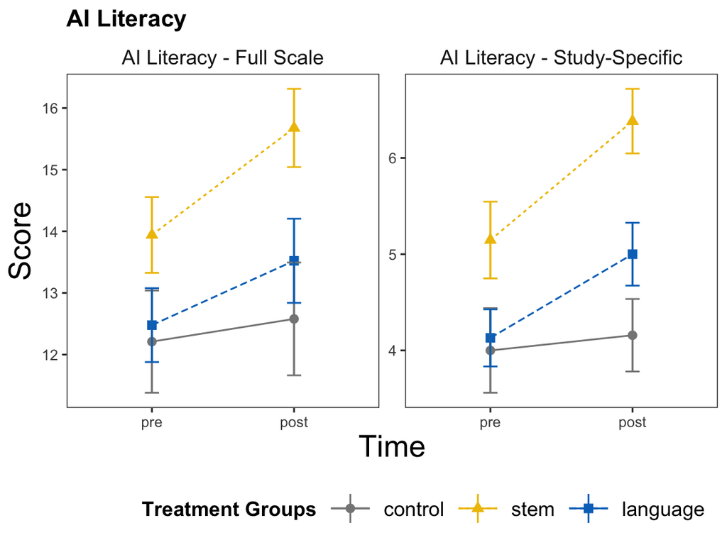

Figure 1: Descriptive Statistics of Students’ AI Literacy Scores Over Time by Treatment Group.

```r
ft_ailit <- modelsummary_models(
  lmers_prepost_all[names(lmers_prepost_all) %in% c("AILIT", "AILITWolke")],
  ddf = "kr",
  output = modelsummary_output,
  # coef_rename = c("genderMännlich" = "Geschlecht")
) # %>%   kableExtra::scroll_box(width = "100%")

if (is_word) {
  ft_ailit <- adjust_table_for_word(ft_ailit, width = .75)
}
ft_ailit
```

Table 2: Summary of Linear Mixed-Effects Models for AI Literacy.

|  | AILIT b | AILIT SE | AILIT t | AILIT p | AILITWolke b | AILITWolke SE | AILITWolke t | AILITWolke p |
| --- | --- | --- | --- | --- | --- | --- | --- | --- |
| (Intercept) | 15.73*** | 1.17 | 13.40 | <0.001 | 5.33*** | 0.61 | 8.75 | <0.001 |
| intervention-c+STEM_language | 2.31* | 1.15 | 2.00 | 0.049 | 1.23* | 0.60 | 2.05 | 0.044 |
| intervention-STEM+language | −0.52 | 1.06 | −0.49 | 0.624 | −1.01+ | 0.55 | −1.82 | 0.073 |
| time-pre+post | 1.05* | 0.41 | 2.54 | 0.013 | 0.75** | 0.26 | 2.90 | 0.005 |
| gender-m+f | −1.41+ | 0.78 | −1.80 | 0.076 | −0.11 | 0.41 | −0.28 | 0.782 |
| semester | −0.28+ | 0.15 | −1.88 | 0.064 | −0.07 | 0.08 | −0.88 | 0.381 |
| location-SGUE+LUE | −0.06 | 1.12 | −0.05 | 0.957 | 0.06 | 0.58 | 0.11 | 0.912 |
| intervention-c+STEM_language:time-pre+post | 1.02 | 0.93 | 1.09 | 0.277 | 0.89 | 0.59 | 1.52 | 0.132 |
| intervention-STEM+language:time-pre+post | −0.69 | 0.95 | −0.73 | 0.467 | −0.37 | 0.60 | −0.61 | 0.541 |
| SD (Intercept code) | 2.42 |  |  |  | 1.09 |  |  |  |
| SD (Observations) | 2.48 |  |  |  | 1.56 |  |  |  |
| Num.Obs. | 152 |  |  |  | 152 |  |  |  |
| R2 Marg. | 0.164 |  |  |  | 0.180 |  |  |  |
| R2 Cond. | 0.572 |  |  |  | 0.448 |  |  |  |
| AIC | 793.9 |  |  |  | 634.5 |  |  |  |
| BIC | 827.2 |  |  |  | 667.8 |  |  |  |
| ICC | 0.5 |  |  |  | 0.3 |  |  |  |
| RMSE | 1.98 |  |  |  | 1.32 |  |  |  |

### 2.2.1 AI Literacy – Full Scale

We did not find a significant main effect of treatment on students’ change in AI literacy, $F(2, 73) = 0.95$, $p = .390$. Neither did the control group’s change differ significantly from both intervention groups, $b = 1.02$, $SE = 0.93$, $t(73.00) = 1.09$, $p= .277$, nor did the change differ significantly between the two intervention groups, $b = -0.69$, $SE = 0.95$, $t(73.00) = -0.73$, $p= .467$.

However, as Figure 1 shows, backened by within-group contrast analyses contrasting the AI literacy score between pre- and posttest (see Online Supplement), students in all treatment conditions improved their AI literacy, while the change in pre-service STEM teachers was significant, $b =1.74$, $SE = 0.60$, $t=2.89$, $p = .005$.

### 2.2.2 AI Literacy – Study-Specific Subset

For the study-specific subset of the AI literacy items, we also did not find a significant main effect of treatment on students’ change in AI literacy, $F(2, 73) = 1.45$, $p = .240$. The control group’s change did not differ significantly from both intervention groups, $b = 0.89$, $SE = 0.59$, $t(73.00) = 1.52$, $p= .132$, nor did the change between the two intervention groups, $b = -0.37$, $SE = 0.60$, $t(73.00) = -0.61$, $p= .541$.

```r
if (!is_word) {
  cat("#### Pairwise Contrasts Within Groups")
}
```

#### 2.2.2.1 Pairwise Contrasts Within Groups

```r
# pairwise within contrasts (no multiplicity adjustment)
ailit_within_contrasts <- lapply(lmers_prepost_all[1:3], function(m) {
  emmeans(m, ~ time | intervention) %>%
    contrast(method = "revpairwise", adjust = "none")
})
if (!is_word) {
  print(ailit_within_contrasts)
}
```

```
$AILIT
intervention = control:
 contrast   estimate    SE df t.ratio p.value
 post - pre    0.368 0.804 73   0.458  0.6480

intervention = stem:
 contrast   estimate    SE df t.ratio p.value
 post - pre    1.735 0.601 73   2.888  0.0051

intervention = language:
 contrast   estimate    SE df t.ratio p.value
 post - pre    1.043 0.731 73   1.428  0.1574

Results are averaged over the levels of: gender, location
Degrees-of-freedom method: kenward-roger

$AILITWolke
intervention = control:
 contrast   estimate    SE df t.ratio p.value
 post - pre    0.158 0.506 73   0.312  0.7559

intervention = stem:
 contrast   estimate    SE df t.ratio p.value
 post - pre    1.235 0.378 73   3.265  0.0017

intervention = language:
 contrast   estimate    SE df t.ratio p.value
 post - pre    0.870 0.460 73   1.890  0.0627

Results are averaged over the levels of: gender, location
Degrees-of-freedom method: kenward-roger

$AILITShort
intervention = control:
 contrast   estimate    SE df t.ratio p.value
 post - pre    0.737 0.470 73   1.567  0.1214

intervention = stem:
 contrast   estimate    SE df t.ratio p.value
 post - pre    1.647 0.352 73   4.686  <.0001

intervention = language:
 contrast   estimate    SE df t.ratio p.value
 post - pre    1.348 0.427 73   3.154  0.0023

Results are averaged over the levels of: gender, location
Degrees-of-freedom method: kenward-roger
```

```r
if (!is_word) {
  cat("#### Pairwise Contrasts Between Groups")
}
```

#### 2.2.2.2 Pairwise Contrasts Between Groups

```r
# pairwise between contrasts (no multiplicity adjustment)
ailit_between_contrasts <- lapply(lmers_prepost_all[1:3], function(m) {
  emmeans(m, ~ intervention * time) %>%
    contrast(interaction = "revpairwise", adjust = "none")
})
if (!is_word) {
  print(ailit_between_contrasts)
}
```

```
$AILIT
 intervention_revpairwise time_revpairwise estimate    SE df t.ratio p.value
 stem - control           post - pre          1.367 1.000 73   1.362  0.1773
 language - control       post - pre          0.675 1.090 73   0.622  0.5362
 language - stem          post - pre         -0.692 0.946 73  -0.731  0.4669

Results are averaged over the levels of: gender, location
Degrees-of-freedom method: kenward-roger

$AILITWolke
 intervention_revpairwise time_revpairwise estimate    SE df t.ratio p.value
 stem - control           post - pre          1.077 0.632 73   1.705  0.0924
 language - control       post - pre          0.712 0.684 73   1.041  0.3015
 language - stem          post - pre         -0.366 0.596 73  -0.614  0.5411

Results are averaged over the levels of: gender, location
Degrees-of-freedom method: kenward-roger

$AILITShort
 intervention_revpairwise time_revpairwise estimate    SE df t.ratio p.value
 stem - control           post - pre          0.910 0.587 73   1.550  0.1254
 language - control       post - pre          0.611 0.635 73   0.962  0.3394
 language - stem          post - pre         -0.299 0.553 73  -0.541  0.5903

Results are averaged over the levels of: gender, location
Degrees-of-freedom method: kenward-roger
```

However, as can be seen in Figure 1, students in both intervention groups showed descriptively higher increases in AI literacy compared to the control group. When performing post-hoc contrasts, we found that students in the STEM course had a marginally significantly higher increase in the study-specific AI literacy compared to the control group, $b =1.08$, $SE = 0.63$, $t=1.71$, $p = .092$, while the difference between students in the language course and the control group was insignificant, $b =0.71$, $SE = 0.68$, $t=1.04$, $p = .301$. All contrast analyses can be accessed in the online supplement at .

## 2.3 Intelligent TPACK and AI Ethics

The descriptive results of students’ ratings of perceived knowledge in Intelligent TPACK and AI ethics are shown in Figure 2, and Table 3 lists the results of the linear mixed-effects models. As can be seen in Figure 2, all pre-service teachers reported their intelligent TPACK knowledge to be around or below the middle of the scale at the pretest, while the intervention groups reported, on average, values significantly higher than the middle value of the scale at the posttest.

For all subscales related to Intelligent TPACK and AI ethics, that is, Intelligent TK, Intelligent TPK, Intelligent TCK, Intelligent TPACK, and AI ethics, we found a significant main effect of treatment on student’ change on the respective subscales. We found significantly higher increases in students’ Intelligent TPACK subscales in both intervention groups compared to the control group, whereas the intervention groups did not differ significantly from each other, see Table 3 for an overview.

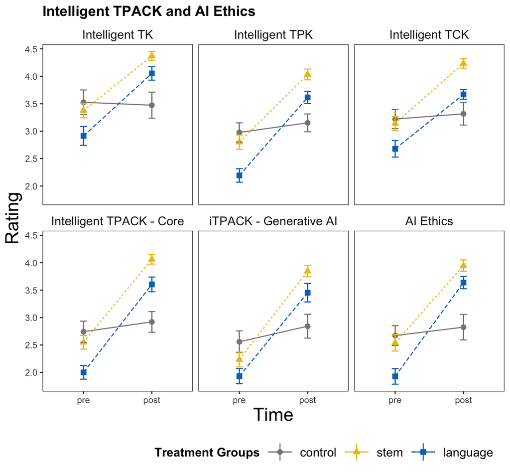

Figure 2: Descriptive Statistics of Students’ Intelligent TPACK and AI Ethics Ratings Over Time by Treatment Group.

```r
ft <- modelsummary_models(
  lmers_prepost_all[grepl("^(T|Ethics)", names(lmers_prepost_all))],
  ddf = "kr",
  output = modelsummary_output,
  # coef_rename = c("genderMännlich" = "Geschlecht")
) # %>%   kableExtra::scroll_box(width = "100%")

if (is_word) {
  ft <- adjust_table_for_word(ft, width = 1)
}
ft
```

Table 3: Summary of Linear Mixed-Effects Models for Intelligent TPACK Subscales and AI Ethics

|  | TK b | TK SE | TK t | TK p | TPK b | TPK SE | TPK t | TPK p | TCK b | TCK SE | TCK t | TCK p | TPACKce b | TPACKce SE | TPACKce t | TPACKce p | TPACKgenai b | TPACKgenai SE | TPACKgenai t | TPACKgenai p | Ethics b | Ethics SE | Ethics t | Ethics p |
| --- | --- | --- | --- | --- | --- | --- | --- | --- | --- | --- | --- | --- | --- | --- | --- | --- | --- | --- | --- | --- | --- | --- | --- | --- |
| (Intercept) | 3.71*** | 0.26 | 14.49 | <0.001 | 3.19*** | 0.21 | 15.01 | <0.001 | 3.70*** | 0.21 | 17.67 | <0.001 | 3.09*** | 0.22 | 13.99 | <0.001 | 2.98*** | 0.23 | 12.75 | <0.001 | 3.28*** | 0.23 | 14.45 | <0.001 |
| intervention-c+STEM_language | 0.39 | 0.25 | 1.56 | 0.124 | 0.24 | 0.21 | 1.15 | 0.252 | 0.50* | 0.21 | 2.45 | 0.017 | 0.58** | 0.22 | 2.67 | 0.009 | 0.46* | 0.23 | 2.01 | 0.048 | 0.62** | 0.22 | 2.78 | 0.007 |
| intervention-STEM+language | −0.08 | 0.23 | −0.36 | 0.720 | −0.33+ | 0.19 | −1.69 | 0.095 | −0.14 | 0.19 | −0.72 | 0.477 | −0.13 | 0.20 | −0.65 | 0.518 | −0.00 | 0.21 | −0.01 | 0.994 | −0.09 | 0.21 | −0.43 | 0.666 |
| time-pre+post | 0.69*** | 0.09 | 7.90 | <0.001 | 0.94*** | 0.09 | 10.73 | <0.001 | 0.73*** | 0.09 | 8.17 | <0.001 | 1.10*** | 0.08 | 13.48 | <0.001 | 1.14*** | 0.11 | 10.45 | <0.001 | 1.09*** | 0.11 | 9.99 | <0.001 |
| gender-m+f | −0.46** | 0.17 | −2.67 | 0.009 | −0.25+ | 0.14 | −1.73 | 0.087 | −0.36* | 0.14 | −2.58 | 0.012 | −0.39* | 0.15 | −2.64 | 0.010 | −0.40* | 0.16 | −2.59 | 0.012 | −0.30+ | 0.15 | −1.99 | 0.051 |
| semester | −0.00 | 0.03 | −0.08 | 0.935 | −0.00 | 0.03 | −0.12 | 0.905 | −0.03 | 0.03 | −1.30 | 0.197 | −0.01 | 0.03 | −0.20 | 0.843 | −0.01 | 0.03 | −0.47 | 0.640 | −0.04 | 0.03 | −1.40 | 0.165 |
| location-SGUE+LUE | −0.29 | 0.24 | −1.19 | 0.237 | −0.19 | 0.20 | −0.94 | 0.352 | −0.33+ | 0.20 | −1.68 | 0.098 | −0.47* | 0.21 | −2.21 | 0.030 | −0.35 | 0.22 | −1.59 | 0.117 | −0.33 | 0.22 | −1.52 | 0.133 |
| intervention-c+STEM_language:time-pre+post | 1.12*** | 0.20 | 5.66 | <0.001 | 1.15*** | 0.20 | 5.82 | <0.001 | 0.95*** | 0.20 | 4.73 | <0.001 | 1.38*** | 0.18 | 7.51 | <0.001 | 1.28*** | 0.25 | 5.22 | <0.001 | 1.41*** | 0.25 | 5.72 | <0.001 |
| intervention-STEM+language:time-pre+post | 0.15 | 0.20 | 0.72 | 0.472 | 0.19 | 0.20 | 0.94 | 0.351 | −0.10 | 0.20 | −0.51 | 0.615 | 0.09 | 0.19 | 0.49 | 0.627 | −0.09 | 0.25 | −0.36 | 0.719 | 0.30 | 0.25 | 1.22 | 0.228 |
| SD (Intercept code) | 0.54 |  |  |  | 0.39 |  |  |  | 0.38 |  |  |  | 0.44 |  |  |  | 0.38 |  |  |  | 0.35 |  |  |  |
| SD (Observations) | 0.53 |  |  |  | 0.53 |  |  |  | 0.53 |  |  |  | 0.49 |  |  |  | 0.65 |  |  |  | 0.65 |  |  |  |
| Num.Obs. | 152 |  |  |  | 152 |  |  |  | 152 |  |  |  | 152 |  |  |  | 152 |  |  |  | 152 |  |  |  |
| R2 Marg. | 0.339 |  |  |  | 0.476 |  |  |  | 0.418 |  |  |  | 0.562 |  |  |  | 0.488 |  |  |  | 0.497 |  |  |  |
| R2 Cond. | 0.676 |  |  |  | 0.664 |  |  |  | 0.611 |  |  |  | 0.760 |  |  |  | 0.615 |  |  |  | 0.607 |  |  |  |
| AIC | 354.6 |  |  |  | 328.7 |  |  |  | 328.2 |  |  |  | 322.9 |  |  |  | 373.5 |  |  |  | 369.3 |  |  |  |
| BIC | 387.8 |  |  |  | 362.0 |  |  |  | 361.4 |  |  |  | 356.1 |  |  |  | 406.7 |  |  |  | 402.6 |  |  |  |
| ICC | 0.5 |  |  |  | 0.4 |  |  |  | 0.3 |  |  |  | 0.5 |  |  |  | 0.2 |  |  |  | 0.2 |  |  |  |
| RMSE | 0.42 |  |  |  | 0.44 |  |  |  | 0.45 |  |  |  | 0.39 |  |  |  | 0.57 |  |  |  | 0.58 |  |  |  |

### 2.3.1 Intelligent TK

We found a significant main effect of treatment on students’ change in intelligent TK, $F(2, 73) = 16.03$, $p < .001$. We found a significant higher increase in students’ intelligent TK in both intervention groups compared to the control group, $b = 1.12$, $SE = 0.20$, $t(73.00) = 5.66$, $p< .001$, while the change did not differ significantly between the two intervention groups, $b = 0.15$, $SE = 0.20$, $t(73.00) = 0.72$, $p= .472$.

### 2.3.4 Intelligent TPACK

For both subscales of the Intelligent TPACK, that is, students’ general TPACK and their perceived competence of applying *generative AI* in teaching their subject, we found a significant main effect of treatment on students’ change on the respective subscales, *TPACK*: $F(2, 73) = 28.24$, $p < .001$, and *TPACK related to generative AI*: $F(2, 73) = 14.00$, $p < .001$.

## 2.4 Perceived Usefulness

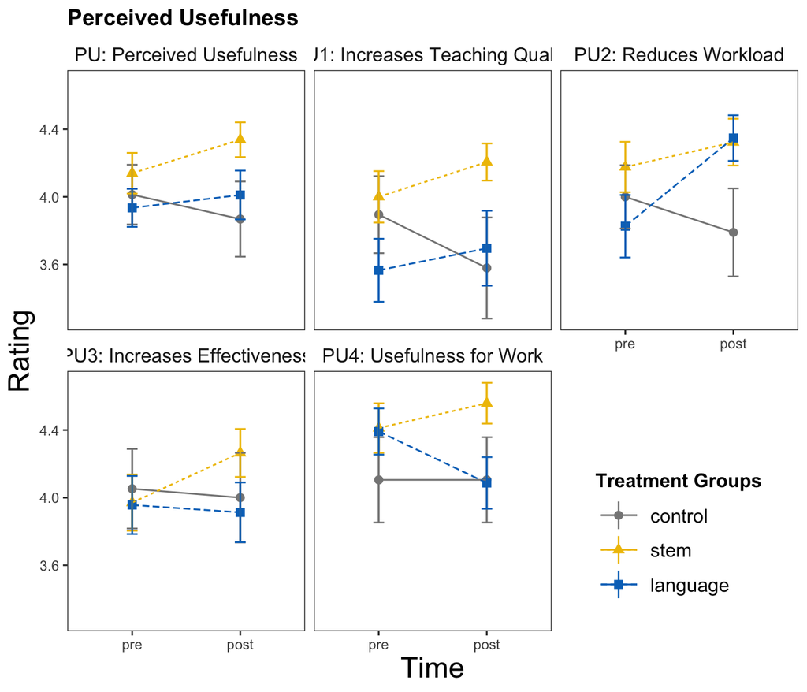

Figure 3: Descriptive Statistics of Students’ Perceived Usefulness Ratings Over Time by Treatment Group.

```r
pu_between_contrasts <- lapply(
  lmers_prepost_all[grepl("^(PU)", names(lmers_prepost_all))],
  function(m) {
    emmeans(m, ~ intervention * time) %>%
      contrast(interaction = "revpairwise", adjust = "none")
  }
)
if (!is_word) {
  print(pu_between_contrasts)
}
```

```
$PU
 intervention_revpairwise time_revpairwise estimate    SE df t.ratio p.value
 stem - control           post - pre          0.343 0.184 73   1.867  0.0659
 language - control       post - pre          0.221 0.199 73   1.110  0.2707
 language - stem          post - pre         -0.122 0.173 73  -0.707  0.4820

Results are averaged over the levels of: gender, location
Degrees-of-freedom method: kenward-roger

$PU1
 intervention_revpairwise time_revpairwise estimate    SE df t.ratio p.value
 stem - control           post - pre         0.5217 0.304 73   1.716  0.0905
 language - control       post - pre         0.4462 0.329 73   1.356  0.1793
 language - stem          post - pre        -0.0754 0.287 73  -0.263  0.7931

Results are averaged over the levels of: gender, location
Degrees-of-freedom method: kenward-roger

$PU2
 intervention_revpairwise time_revpairwise estimate    SE df t.ratio p.value
 stem - control           post - pre          0.358 0.313 73   1.143  0.2570
 language - control       post - pre          0.732 0.339 73   2.162  0.0339
 language - stem          post - pre          0.375 0.295 73   1.270  0.2081

Results are averaged over the levels of: gender, location
Degrees-of-freedom method: kenward-roger

$PU3
 intervention_revpairwise time_revpairwise estimate    SE df t.ratio p.value
 stem - control           post - pre        0.34675 0.262 73   1.325  0.1894
 language - control       post - pre        0.00915 0.283 73   0.032  0.9743
 language - stem          post - pre       -0.33760 0.247 73  -1.368  0.1754

Results are averaged over the levels of: gender, location
Degrees-of-freedom method: kenward-roger

$PU4
 intervention_revpairwise time_revpairwise estimate    SE df t.ratio p.value
 stem - control           post - pre          0.147 0.225 73   0.653  0.5158
 language - control       post - pre         -0.304 0.244 73  -1.249  0.2158
 language - stem          post - pre         -0.451 0.212 73  -2.126  0.0369

Results are averaged over the levels of: gender, location
Degrees-of-freedom method: kenward-roger
```

```r
ft_pu <- modelsummary_models(
  lmers_prepost_all[grepl("^(PU)", names(lmers_prepost_all))],
  ddf = "kr",
  output = modelsummary_output,
  # coef_rename = c("genderMännlich" = "Geschlecht")
) # %>%   kableExtra::scroll_box(width = "100%")

if (is_word) {
  ft_pu <- ft_pu %>% adjust_table_for_word()
}
ft_pu
```

Table 4: Summary of Linear Mixed-Effects Models for Perceived Usefulness.

|  | PU b | PU SE | PU t | PU p | PU1 b | PU1 SE | PU1 t | PU1 p | PU2 b | PU2 SE | PU2 t | PU2 p | PU3 b | PU3 SE | PU3 t | PU3 p | PU4 b | PU4 SE | PU4 t | PU4 p |
| --- | --- | --- | --- | --- | --- | --- | --- | --- | --- | --- | --- | --- | --- | --- | --- | --- | --- | --- | --- | --- |
| (Intercept) | 3.83*** | 0.24 | 16.24 | <0.001 | 3.28*** | 0.30 | 11.03 | <0.001 | 4.25*** | 0.26 | 16.48 | <0.001 | 3.79*** | 0.30 | 12.69 | <0.001 | 4.01*** | 0.29 | 13.79 | <0.001 |
| intervention-c+STEM_language | −0.07 | 0.23 | −0.30 | 0.762 | −0.24 | 0.29 | −0.81 | 0.420 | 0.31 | 0.25 | 1.21 | 0.232 | −0.34 | 0.29 | −1.16 | 0.249 | −0.01 | 0.29 | −0.03 | 0.977 |
| intervention-STEM+language | −0.31 | 0.21 | −1.45 | 0.153 | −0.69* | 0.27 | −2.55 | 0.013 | 0.01 | 0.23 | 0.04 | 0.965 | −0.22 | 0.27 | −0.83 | 0.411 | −0.34 | 0.26 | −1.27 | 0.207 |
| time-pre+post | 0.04 | 0.08 | 0.57 | 0.570 | 0.01 | 0.13 | 0.05 | 0.957 | 0.15 | 0.13 | 1.18 | 0.240 | 0.07 | 0.11 | 0.61 | 0.543 | −0.05 | 0.09 | −0.56 | 0.574 |
| gender-m+f | −0.36* | 0.16 | −2.29 | 0.025 | −0.22 | 0.20 | −1.11 | 0.272 | −0.37* | 0.17 | −2.16 | 0.034 | −0.55** | 0.20 | −2.76 | 0.007 | −0.30 | 0.19 | −1.54 | 0.128 |
| semester | 0.04 | 0.03 | 1.23 | 0.222 | 0.08* | 0.04 | 2.05 | 0.044 | −0.01 | 0.03 | −0.44 | 0.658 | 0.04 | 0.04 | 1.12 | 0.267 | 0.04 | 0.04 | 1.14 | 0.256 |
| location-SGUE+LUE | 0.15 | 0.22 | 0.68 | 0.498 | 0.18 | 0.28 | 0.63 | 0.529 | −0.00 | 0.25 | −0.02 | 0.987 | 0.26 | 0.28 | 0.92 | 0.360 | 0.18 | 0.28 | 0.63 | 0.529 |
| intervention-c+STEM_language:time-pre+post | 0.28 | 0.17 | 1.65 | 0.103 | 0.48+ | 0.28 | 1.71 | 0.091 | 0.54+ | 0.29 | 1.87 | 0.065 | 0.18 | 0.24 | 0.73 | 0.467 | −0.08 | 0.21 | −0.38 | 0.708 |
| intervention-STEM+language:time-pre+post | −0.12 | 0.17 | −0.71 | 0.482 | −0.08 | 0.29 | −0.26 | 0.793 | 0.37 | 0.30 | 1.27 | 0.208 | −0.34 | 0.25 | −1.37 | 0.175 | −0.45* | 0.21 | −2.13 | 0.037 |
| SD (Intercept code) | 0.51 |  |  |  | 0.54 |  |  |  | 0.36 |  |  |  | 0.61 |  |  |  | 0.63 |  |  |  |
| SD (Observations) | 0.45 |  |  |  | 0.75 |  |  |  | 0.77 |  |  |  | 0.65 |  |  |  | 0.56 |  |  |  |
| Num.Obs. | 152 |  |  |  | 152 |  |  |  | 152 |  |  |  | 152 |  |  |  | 152 |  |  |  |
| R2 Marg. | 0.138 |  |  |  | 0.124 |  |  |  | 0.094 |  |  |  | 0.134 |  |  |  | 0.101 |  |  |  |
| R2 Cond. | 0.617 |  |  |  | 0.421 |  |  |  | 0.257 |  |  |  | 0.540 |  |  |  | 0.603 |  |  |  |
| AIC | 321.5 |  |  |  | 427.4 |  |  |  | 411.5 |  |  |  | 406.3 |  |  |  | 380.3 |  |  |  |
| BIC | 354.8 |  |  |  | 460.6 |  |  |  | 444.8 |  |  |  | 439.6 |  |  |  | 413.6 |  |  |  |
| ICC | 0.6 |  |  |  | 0.3 |  |  |  | 0.2 |  |  |  | 0.5 |  |  |  | 0.6 |  |  |  |
| RMSE | 0.36 |  |  |  | 0.63 |  |  |  | 0.69 |  |  |  | 0.52 |  |  |  | 0.43 |  |  |  |

```r
lmers_pu <- lmers_prepost_all[grepl("^(PU)", names(lmers_prepost_all))]
tab_models(lmers_pu)
```

Summary of Linear Mixed-Effects Models for Perceived Usefulness.

|  | PU |  |  |  | PU1 |  |  |  | PU2 |  |  |  | PU3 |  |  |  | PU4 |  |  |  |
| --- | --- | --- | --- | --- | --- | --- | --- | --- | --- | --- | --- | --- | --- | --- | --- | --- | --- | --- | --- | --- |
| Predictors | b | SE | t | p | b | SE | t | p | b | SE | t | p | b | SE | t | p | b | SE | t | p |
| (Intercept) | 3.83 *** | 0.24 | 16.24 | **<0.001** | 3.28 *** | 0.30 | 11.03 | **<0.001** | 4.25 *** | 0.26 | 16.48 | **<0.001** | 3.79 *** | 0.30 | 12.69 | **<0.001** | 4.01 *** | 0.29 | 13.79 | **<0.001** |
| intervention-c+STEM language | -0.07 | 0.23 | -0.30 | 0.762 | -0.24 | 0.29 | -0.81 | 0.420 | 0.31 | 0.25 | 1.21 | 0.232 | -0.34 | 0.29 | -1.16 | 0.249 | -0.01 | 0.29 | -0.03 | 0.977 |
| intervention-STEM+language | -0.31 | 0.21 | -1.45 | 0.153 | -0.69 * | 0.27 | -2.55 | **0.013** | 0.01 | 0.23 | 0.04 | 0.965 | -0.22 | 0.27 | -0.83 | 0.411 | -0.34 | 0.26 | -1.27 | 0.207 |
| time-pre+post | 0.04 | 0.08 | 0.57 | 0.570 | 0.01 | 0.13 | 0.05 | 0.957 | 0.15 | 0.13 | 1.18 | 0.240 | 0.07 | 0.11 | 0.61 | 0.543 | -0.05 | 0.09 | -0.56 | 0.574 |
| gender-m+f | -0.36 * | 0.16 | -2.29 | **0.025** | -0.22 | 0.20 | -1.11 | 0.272 | -0.37 * | 0.17 | -2.16 | **0.034** | -0.55 ** | 0.20 | -2.76 | **0.007** | -0.30 | 0.19 | -1.54 | 0.128 |
| semester | 0.04 | 0.03 | 1.23 | 0.222 | 0.08 * | 0.04 | 2.05 | **0.044** | -0.01 | 0.03 | -0.44 | 0.658 | 0.04 | 0.04 | 1.12 | 0.267 | 0.04 | 0.04 | 1.14 | 0.256 |
| location-SGUE+LUE | 0.15 | 0.22 | 0.68 | 0.498 | 0.18 | 0.28 | 0.63 | 0.529 | -0.00 | 0.25 | -0.02 | 0.987 | 0.26 | 0.28 | 0.92 | 0.360 | 0.18 | 0.28 | 0.63 | 0.529 |
| intervention-c+STEM language × time-pre+post | 0.28 | 0.17 | 1.65 | 0.103 | 0.48 | 0.28 | 1.71 | 0.091 | 0.54 | 0.29 | 1.87 | 0.065 | 0.18 | 0.24 | 0.73 | 0.467 | -0.08 | 0.21 | -0.38 | 0.708 |
| intervention-STEM+language × time-pre+post | -0.12 | 0.17 | -0.71 | 0.482 | -0.08 | 0.29 | -0.26 | 0.793 | 0.37 | 0.30 | 1.27 | 0.208 | -0.34 | 0.25 | -1.37 | 0.175 | -0.45 * | 0.21 | -2.13 | **0.037** |
| Random Effects |  |  |  |  |  |  |  |  |  |  |  |  |  |  |  |  |  |  |  |  |
| σ<sup>2</sup> | 0.21 |  |  |  | 0.56 |  |  |  | 0.60 |  |  |  | 0.42 |  |  |  | 0.31 |  |  |  |
| τ<sub>00</sub> | 0.26 <sub>code</sub> |  |  |  | 0.29 <sub>code</sub> |  |  |  | 0.13 <sub>code</sub> |  |  |  | 0.37 <sub>code</sub> |  |  |  | 0.39 <sub>code</sub> |  |  |  |
| ICC | 0.56 |  |  |  | 0.34 |  |  |  | 0.18 |  |  |  | 0.47 |  |  |  | 0.56 |  |  |  |
| N | 76 <sub>code</sub> |  |  |  | 76 <sub>code</sub> |  |  |  | 76 <sub>code</sub> |  |  |  | 76 <sub>code</sub> |  |  |  | 76 <sub>code</sub> |  |  |  |
| Observations | 152 |  |  |  | 152 |  |  |  | 152 |  |  |  | 152 |  |  |  | 152 |  |  |  |
| Marginal R<sup>2</sup> / Conditional R<sup>2</sup> | 0.138 / 0.617 |  |  |  | 0.124 / 0.421 |  |  |  | 0.094 / 0.257 |  |  |  | 0.134 / 0.540 |  |  |  | 0.101 / 0.603 |  |  |  |
| * p<0.05 ** p<0.01 *** p<0.001 |  |  |  |  |  |  |  |  |  |  |  |  |  |  |  |  |  |  |  |  |

For the overall perceived usefulness, we did not find a significant main effect of treatment on students’ change in perceived usefulness, $F(2, 73) = 1.74$, $p = .182$. Neither did the control group’s change differ significantly from both intervention groups, $b = 0.28$, $SE = 0.17$, $t(73.00) = 1.65$, $p= .103$, nor did the change differ significantly between the two intervention groups, $b = -0.12$, $SE = 0.17$, $t(73.00) = -0.71$, $p= .482$.

**Note**

wir können für uns noch die Kontraste für PU anschauen. Hier ist interessant, dass für PU1 stem > control und PU2 language > control